# Homework

```r
library(tidyverse)
library(lubridate)
library(tsibble)
library(tsibbledata)
library(fable)
```

```r
nyc_bikes
```

| bike_id | start_time | stop_time | start_station | start_lat | start_long | end_station | end_lat | end_long | type | birth_year | gender |
| --- | --- | --- | --- | --- | --- | --- | --- | --- | --- | --- | --- |
| 26301 | 2018-02-26 19:11:03 | 2018-02-26 19:15:40 | 3186 | 40.71959 | -74.04312 | 3203 | 40.72760 | -74.04425 | Subscriber | 1986 | Male |
| 26301 | 2018-02-27 07:52:49 | 2018-02-27 07:58:13 | 3203 | 40.72760 | -74.04425 | 3202 | 40.72722 | -74.03376 | Subscriber | 1979 | Male |
| 26301 | 2018-02-27 12:03:27 | 2018-02-27 12:04:54 | 3202 | 40.72722 | -74.03376 | 3638 | 40.72429 | -74.03548 | Subscriber | 1963 | Male |
| 26301 | 2018-02-27 13:53:51 | 2018-02-27 14:21:04 | 3638 | 40.72429 | -74.03548 | 3638 | 40.72429 | -74.03548 | Subscriber | 1984 | Male |
| 26301 | 2018-02-27 14:30:42 | 2018-02-27 14:33:11 | 3638 | 40.72429 | -74.03548 | 3187 | 40.72112 | -74.03805 | Subscriber | 1980 | Male |
| 26301 | 2018-02-27 16:31:04 | 2018-02-27 16:33:27 | 3187 | 40.72112 | -74.03805 | 3638 | 40.72429 | -74.03548 | Subscriber | 1980 | Male |
| 26301 | 2018-02-27 17:37:12 | 2018-02-27 17:40:49 | 3638 | 40.72429 | -74.03548 | 3639 | 40.71925 | -74.03423 | Subscriber | 1989 | Male |
| 26301 | 2018-02-27 17:49:10 | 2018-02-27 17:55:03 | 3639 | 40.71925 | -74.03423 | 3202 | 40.72722 | -74.03376 | Subscriber | 1962 | Male |
| 26301 | 2018-02-27 18:21:57 | 2018-02-27 18:25:18 | 3202 | 40.72722 | -74.03376 | 3638 | 40.72429 | -74.03548 | Subscriber | 1992 | Male |
| 26301 | 2018-02-27 22:08:55 | 2018-02-27 22:28:42 | 3638 | 40.72429 | -74.03548 | 3281 | 40.74591 | -74.05727 | Subscriber | 1981 | Male |

[output cut: 990 more lines]

```r
names(nyc_bikes)
```

```
 [1] "bike_id"       "start_time"    "stop_time"     "start_station" "start_lat"     "start_long"
 [7] "end_station"   "end_lat"       "end_long"      "type"          "birth_year"    "gender"
```

Question 1

```r
nyc_bikes_1 <- nyc_bikes %>%
  mutate(year = year(start_time),
         month = month(start_time),
         date = date(start_time))
```

Question 2

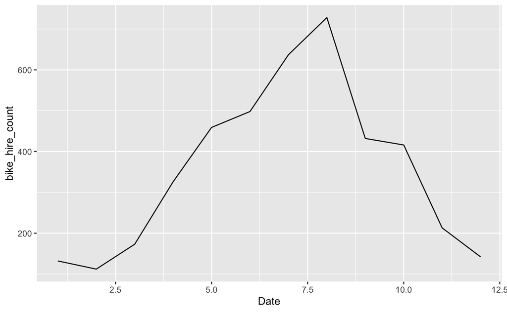

```r
nyc_bikes_1 %>%
  index_by(month) %>%
  summarise(bike_hire_count = n()) %>%
  ggplot(aes(month, bike_hire_count)) +
  geom_line() +
  xlab("Date")
```

Shows that the bike hire is seasonal throughout the year, peaking around July/August. This increase likely coincides with the increase in good weather. It gives a general idea of the forecast but it is not very precise. Seeing as the data has multiple bike hires in some days, I would probably only downsample this data to weekly.

Question 3

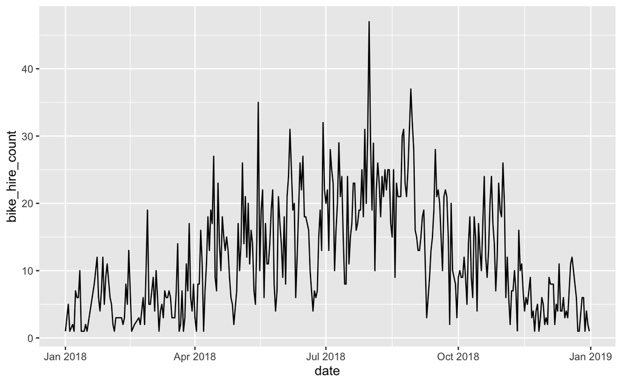

```r
nyc_bikes_3 <- nyc_bikes_1 %>%
  index_by(date) %>%
  summarise(bike_hire_count = n())

nyc_bikes_3 %>%
  ggplot(aes(date, bike_hire_count)) +
  geom_line()
```

Question 4

```r
nyc_bikes_4 <- nyc_bikes_3 %>%
  fill_gaps(bike_hire_count = as.integer(median(bike_hire_count)))

fit <- nyc_bikes_4 %>%
  model(
    snaive = SNAIVE(bike_hire_count),
    mean_model = MEAN(bike_hire_count),
    arima = ARIMA(bike_hire_count)
  )
fit
```

| snaive | mean_model | arima |
| --- | --- | --- |

question 5

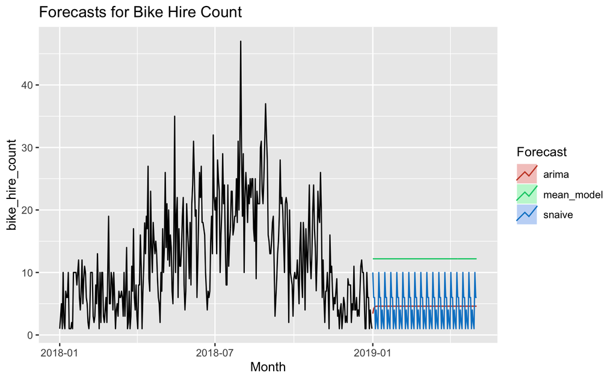

```r
forecast_4m <- fit %>%
  fabletools::forecast(h = "4 months")

forecast_4m %>%
  autoplot(nyc_bikes_4, level = NULL) +
  ggtitle("Forecasts for Bike Hire Count") +
  xlab("Month") +
  guides(colour = guide_legend(title = "Forecast"))
```

question 6

```
Plot variable not specified, automatically selected `.vars = bike_hire_count`
```

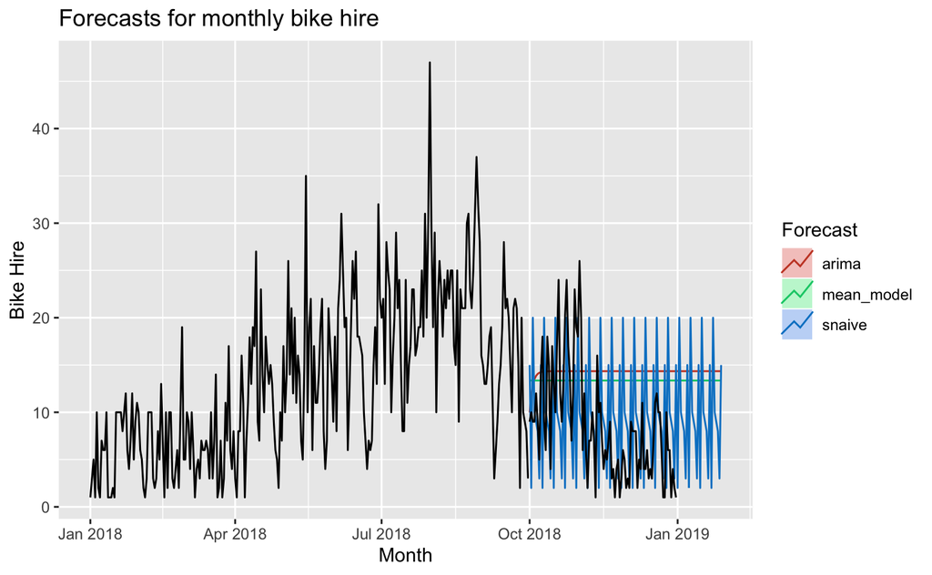

```r
train <- nyc_bikes_4 %>%
  filter_index("2018-01" ~ "2018-09")

fit_test <- train %>%
  model(
    mean_model = MEAN(bike_hire_count),
    arima = ARIMA(bike_hire_count),
    snaive = SNAIVE(bike_hire_count))


forecast_test <- fit_test %>%
  fabletools::forecast(h = 120)

forecast_test %>%
  autoplot(train, level = NULL) +
    autolayer(filter_index(nyc_bikes_4, "2018-10" ~ .), color = "black") +
    ggtitle("Forecasts for monthly bike hire") +
    xlab("Month") + ylab("Bike Hire") +
    guides(colour = guide_legend(title = "Forecast"))
```

```r
accuracy_model <- fabletools::accuracy(forecast_test, nyc_bikes_4)
```

```
The future dataset is incomplete, incomplete out-of-sample data will be treated as missing.
28 observations are missing between 2019-01-01 and 2019-01-28
```

```r
accuracy_model %>%
  select(-.type) %>%
  arrange(RMSE)
```

| .model | ME | RMSE | MAE | MPE | MAPE | MASE | ACF1 |
| --- | --- | --- | --- | --- | --- | --- | --- |
| mean_model | -4.652453 | 7.529973 | 6.671962 | -199.9505 | 209.8097 | 0.9645337 | 0.59140862 |
| snaive | -0.923913 | 7.863648 | 6.250000 | -103.7575 | 143.9805 | 0.9035326 | -0.01495561 |
| arima | -5.525435 | 8.127051 | 7.197151 | -220.8721 | 228.8474 | 1.0404576 | 0.59294534 |

Question 7 The forecast doesn’t appear to be accurate as it clearly does not follow the trend of the data in the model test so none of the models are a good fit for the data. Could potentially ask for more data (I don’t really understand the errors enough to test a different model)

Question 8

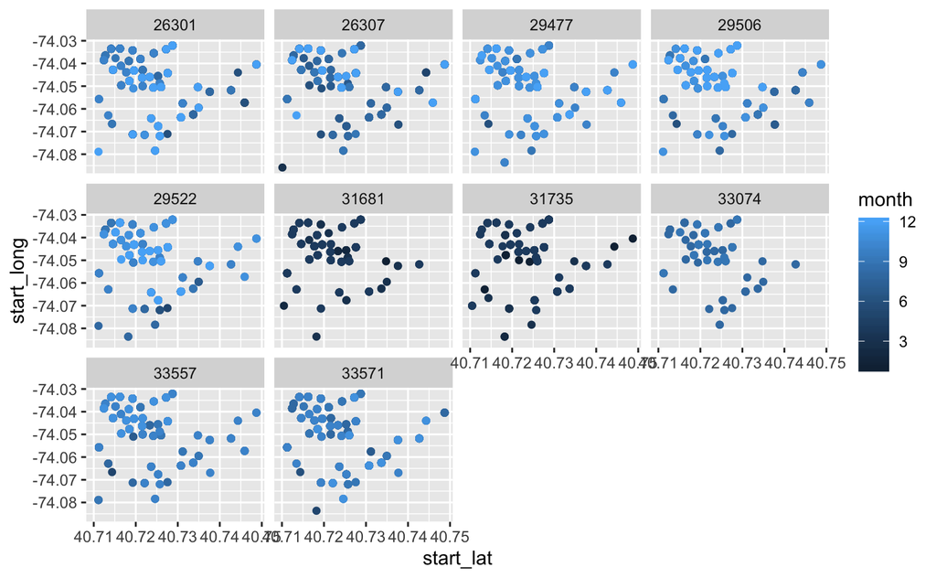

```r
nyc_bikes_1 %>%
  ggplot(aes(x = start_lat, y = start_long, colour = month)) +
  geom_point() +
  facet_wrap(~ bike_id)
```

Bikes 31681 & 31735 were only used in the first half of the year whereas the otheres were hired more in the 2nd half of the year.

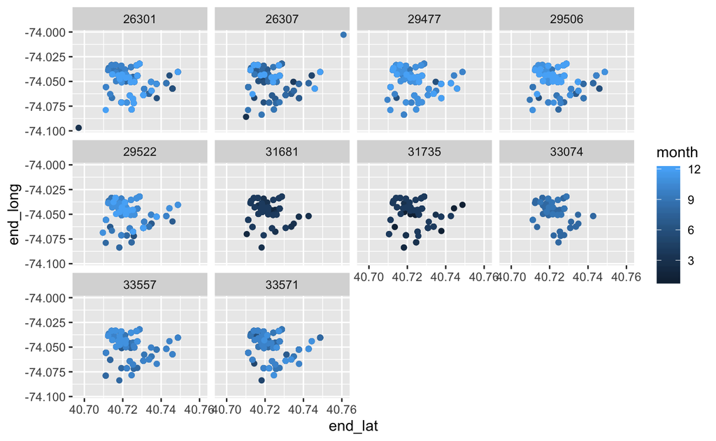

```r
nyc_bikes_1 %>%
  ggplot(aes(x = end_lat, y = end_long, colour = month)) +
  geom_point() +
  facet_wrap(~ bike_id)
```

Very little change which is unsurprising as the bikes were hired and returned in the same day generally..?

Question 9

```r
library(leaflet)
```

```r
bike_hire_map <- leaflet(nyc_bikes) %>%
  addTiles() %>%
  addMarkers(lng = ~ start_long, lat = ~start_lat,
             clusterOptions = markerClusterOptions())

bike_hire_map
```

[interactive chart not shown]

```r
NA
```

Question 10

```r
bike_hire_map_lines <- leaflet(nyc_bikes) %>%
  addTiles() %>%
  addMarkers(lng = ~ start_long, lat = ~start_lat,
             clusterOptions = markerClusterOptions()
             ) %>%
  addPolylines(lng = ~ end_long, lat = ~end_lat)
# Need a for loop to only show the line for the selected pin i think.. but it's too late at night

bike_hire_map_lines
```

[interactive chart not shown]